# Lab 6 — Confidence Intervals & Regression Basics

Quantitative Reasoning · LAB 413

Instructor: Subin Na

October 15, 2025

> **How to use this document.** Run the code along with me. Comments start with `#`. Each section mirrors the live lab; code chunks show the command and its output together.

**Today’s plan**

1. Clean environment + setup
2. Load & inspect the `Prestige` data
3. Visualize distributions
4. Linear regression: `prestige ~ education`
5. Confidence intervals for the coefficients
6. Quick practice
7. Wrap-up

# 1 Clean Environment + Setup

```r
rm(list = ls())   # clean environment

# Load the packages
library(ggplot2)
library(dplyr)
library(carData)  # contains the Prestige dataset
```

# 2 Load & Inspect the Prestige Data

```r
data("Prestige")

# In RStudio you would run View(Prestige); here we preview the first rows.
knitr::kable(head(Prestige), caption = "First rows of the Prestige data")
```

First rows of the Prestige data

|  | education | income | women | prestige | census | type |
| --- | --- | --- | --- | --- | --- | --- |
| gov.administrators | 13.11 | 12351 | 11.16 | 68.8 | 1113 | prof |
| general.managers | 12.26 | 25879 | 4.02 | 69.1 | 1130 | prof |
| accountants | 12.77 | 9271 | 15.70 | 63.4 | 1171 | prof |
| purchasing.officers | 11.42 | 8865 | 9.11 | 56.8 | 1175 | prof |
| chemists | 14.62 | 8403 | 11.68 | 73.5 | 2111 | prof |
| physicists | 15.64 | 11030 | 5.13 | 77.6 | 2113 | prof |

```r
summary(Prestige)
```

```
#>    education          income          women           prestige
#>  Min.   : 6.380   Min.   :  611   Min.   : 0.000   Min.   :14.80
#>  1st Qu.: 8.445   1st Qu.: 4106   1st Qu.: 3.592   1st Qu.:35.23
#>  Median :10.540   Median : 5930   Median :13.600   Median :43.60
#>  Mean   :10.738   Mean   : 6798   Mean   :28.979   Mean   :46.83
#>  3rd Qu.:12.648   3rd Qu.: 8187   3rd Qu.:52.203   3rd Qu.:59.27
#>  Max.   :15.970   Max.   :25879   Max.   :97.510   Max.   :87.20
#>      census       type
#>  Min.   :1113   bc  :44
#>  1st Qu.:3120   prof:31
#>  Median :5135   wc  :23
#>  Mean   :5402   NA's: 4
#>  3rd Qu.:8312
#>  Max.   :9517
```

> **Variable notes**
> - `income` = average income (in Canadian dollars)
> - `education` = average years of education
> - `women` = % of women in the occupation
> - `prestige` = social prestige score (our dependent variable)

# 3 Visualize Distributions

**Histogram of prestige (default binning).**

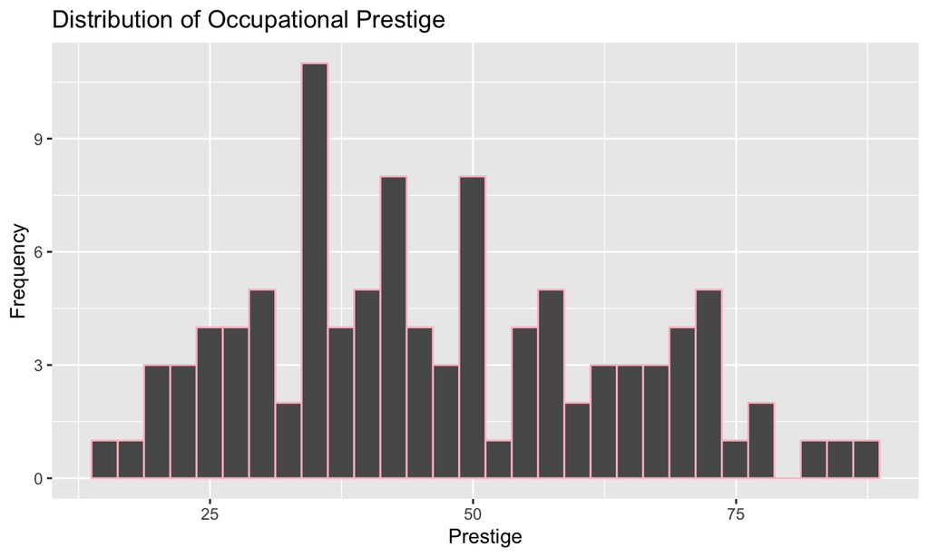

```r
ggplot(Prestige, aes(x = prestige)) +
  geom_histogram(color = "pink") +
  labs(title = "Distribution of Occupational Prestige",
       x = "Prestige", y = "Frequency")
```

**Histogram of prestige (fixed bin width).**

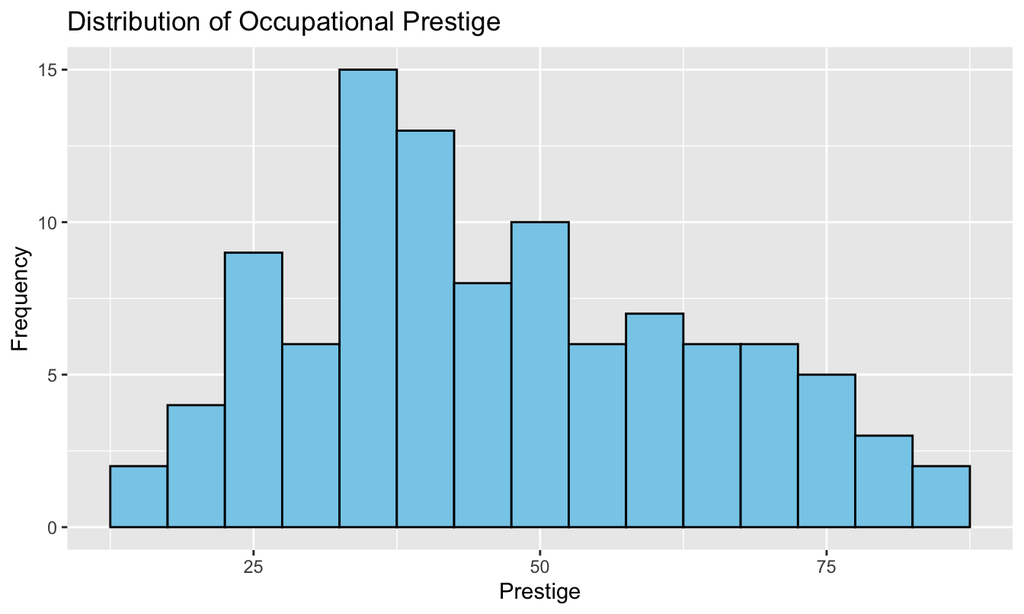

```r
ggplot(Prestige, aes(x = prestige)) +
  geom_histogram(binwidth = 5, fill = "skyblue", color = "black") +
  labs(title = "Distribution of Occupational Prestige",
       x = "Prestige", y = "Frequency")
```

**Histogram of education.**

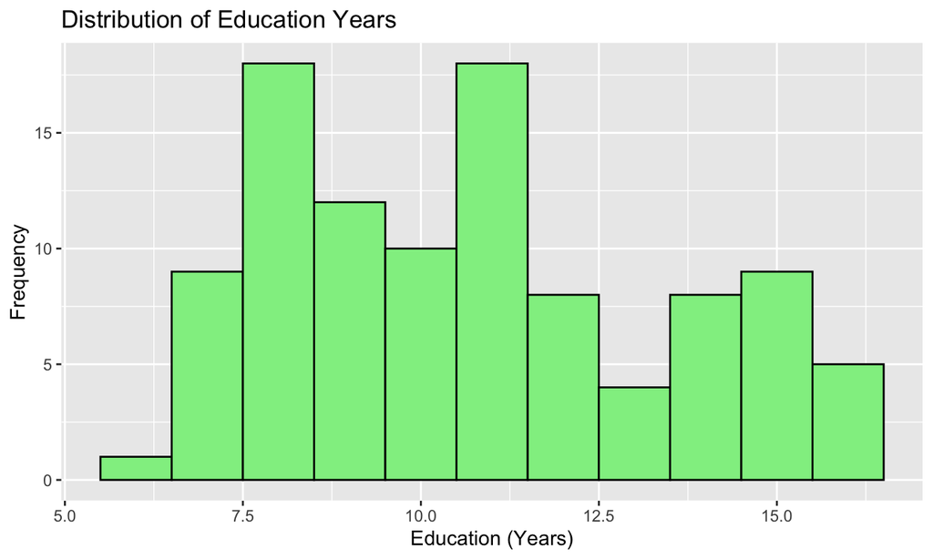

```r
ggplot(Prestige, aes(x = education)) +
  geom_histogram(binwidth = 1, fill = "lightgreen", color = "black") +
  labs(title = "Distribution of Education Years",
       x = "Education (Years)", y = "Frequency")
```

# 4 Linear Regression: `prestige ~ education`

Predict the social prestige score from years of education.

```r
model <- lm(prestige ~ education, data = Prestige)
summary(model)
```

```
#>
#> Call:
#> lm(formula = prestige ~ education, data = Prestige)
#>
#> Residuals:
#>      Min       1Q   Median       3Q      Max
#> -26.0397  -6.5228   0.6611   6.7430  18.1636
#>
#> Coefficients:
#>             Estimate Std. Error t value Pr(>|t|)
#> (Intercept)  -10.732      3.677  -2.919  0.00434 **
#> education      5.361      0.332  16.148  < 2e-16 ***
#> ---
#> Signif. codes:  0 '***' 0.001 '**' 0.01 '*' 0.05 '.' 0.1 ' ' 1
#>
#> Residual standard error: 9.103 on 100 degrees of freedom
#> Multiple R-squared:  0.7228, Adjusted R-squared:   0.72
#> F-statistic: 260.8 on 1 and 100 DF,  p-value: < 2.2e-16
```

> - **Intercept** = predicted prestige when `education` = 0.
> - **education** = expected change in prestige for a 1-year increase in education.

# 5 Confidence Intervals (95%)

```r
confint(model, level = 0.95)
```

```
#>                  2.5 %    97.5 %
#> (Intercept) -18.027220 -3.436744
#> education     4.702223  6.019533
```

```r
# Lower and upper bounds for each coefficient
```

# 6 Quick Practice

**P1) Add `income` as another predictor.** Include multiple predictors by connecting them with `+`. Compare coefficients and *p*-values.

```r
model2 <- lm(prestige ~ education + income, data = Prestige)
summary(model2)
```

```
#>
#> Call:
#> lm(formula = prestige ~ education + income, data = Prestige)
#>
#> Residuals:
#>      Min       1Q   Median       3Q      Max
#> -19.4040  -5.3308   0.0154   4.9803  17.6889
#>
#> Coefficients:
#>               Estimate Std. Error t value Pr(>|t|)
#> (Intercept) -6.8477787  3.2189771  -2.127   0.0359 *
#> education    4.1374444  0.3489120  11.858  < 2e-16 ***
#> income       0.0013612  0.0002242   6.071 2.36e-08 ***
#> ---
#> Signif. codes:  0 '***' 0.001 '**' 0.01 '*' 0.05 '.' 0.1 ' ' 1
#>
#> Residual standard error: 7.81 on 99 degrees of freedom
#> Multiple R-squared:  0.798,  Adjusted R-squared:  0.7939
#> F-statistic: 195.6 on 2 and 99 DF,  p-value: < 2.2e-16
```

**P2) Using `confint`, which predictors have CIs that include 0?**

```r
confint(model2, level = 0.95)
```

```
#>                     2.5 %       97.5 %
#> (Intercept) -1.323493e+01 -0.460629799
#> education    3.445127e+00  4.829761535
#> income       9.162805e-04  0.001806051
```

**P3) Try predicting prestige using the % of women.**

```r
model_women <- lm(prestige ~ women, data = Prestige)
summary(model_women)
```

```
#>
#> Call:
#> lm(formula = prestige ~ women, data = Prestige)
#>
#> Residuals:
#>     Min      1Q  Median      3Q     Max
#> -33.444 -12.391  -4.126  13.034  39.185
#>
#> Coefficients:
#>             Estimate Std. Error t value Pr(>|t|)
#> (Intercept) 48.69300    2.30760  21.101   <2e-16 ***
#> women       -0.06417    0.05385  -1.192    0.236
#> ---
#> Signif. codes:  0 '***' 0.001 '**' 0.01 '*' 0.05 '.' 0.1 ' ' 1
#>
#> Residual standard error: 17.17 on 100 degrees of freedom
#> Multiple R-squared:  0.014,  Adjusted R-squared:  0.004143
#> F-statistic:  1.42 on 1 and 100 DF,  p-value: 0.2362
```

```r
confint(model_women, level = 0.95)
```

```
#>                 2.5 %      97.5 %
#> (Intercept) 44.114782 53.27121657
#> women       -0.171008  0.04266233
```

# 7 Wrap-up

**Key takeaways**

- `confint()` gives the CI for regression coefficients.
- *p*-values tell us whether relationships are statistically significant.
- Education and income often predict social prestige — a core social science insight.
- A CI that includes 0 means the predictor is not statistically distinguishable from “no effect.”
- Next week: one-sample *t*-test for group means.